# Human Activity Recognition

Avinash Dodda - Aug 2019

# 1 Background

Using devices such as Jawbone Up, Nike FuelBand, and Fitbit it is now possible to collect a large amount of data about personal activity relatively inexpensively. One thing that people regularly do is quantify how much of a particular activity they do, but they rarely quantify how well they do it. In this project, our goal will be to use data from accelerometers on the belt, forearm, arm, and dumbbell of 6 participants. They were asked to perform barbell lifts correctly and incorrectly in 5 different ways. More information is available from the website here: http://web.archive.org/web/20161224072740/http:/groupware.les.inf.puc-rio.br/har (see the section on the Weight Lifting Exercise Data set).

# 2 Data

The training data for this project are available here:

https://d396qusza40orc.cloudfront.net/predmachlearn/pml-training.csv

The test data are available here:

https://d396qusza40orc.cloudfront.net/predmachlearn/pml-testing.csv

The data for this project come from this source: http://web.archive.org/web/20161224072740/http:/groupware.les.inf.puc-rio.br/har.

# 3 Goal

The goal of this project is to predict the manner in which the people did the exercise. This is represented by the “classe” variable in the training set. We use other variables from the data set to predict the classe.

# 4 Load Required Packages and Set Seed

```r
library(caret)
library(rpart)
library(rpart.plot)
library(randomForest)
library(rattle)
library(RColorBrewer)
set.seed(100)
```

# 5 Read Data

```r
trainurl <- "https://d396qusza40orc.cloudfront.net/predmachlearn/pml-training.csv"
testurl <- "https://d396qusza40orc.cloudfront.net/predmachlearn/pml-testing.csv"

train <- read.csv(trainurl)
test <- read.csv(testurl)
```

Check dimensions of train data set

```r
dim(train)
```

```
## [1] 19622   160
```

Check dimensions of test data set

```r
dim(test)
```

```
## [1]  20 160
```

# 6 Cleaning Data

We first look at the summary of train data

```r
str(train)
```

```
## 'data.frame':    19622 obs. of  160 variables:
##  $ X                       : int  1 2 3 4 5 6 7 8 9 10 ...
##  $ user_name               : Factor w/ 6 levels "adelmo","carlitos",..: 2 2 2 2 2 2 2 2 2 2 ...
##  $ raw_timestamp_part_1    : int  1323084231 1323084231 1323084231 1323084232 1323084232 1323084232 1323084232 1323084232 1323084232 1323084232 ...
##  $ raw_timestamp_part_2    : int  788290 808298 820366 120339 196328 304277 368296 440390 484323 484434 ...
##  $ cvtd_timestamp          : Factor w/ 20 levels "02/12/2011 13:32",..: 9 9 9 9 9 9 9 9 9 9 ...
##  $ new_window              : Factor w/ 2 levels "no","yes": 1 1 1 1 1 1 1 1 1 1 ...
##  $ num_window              : int  11 11 11 12 12 12 12 12 12 12 ...
##  $ roll_belt               : num  1.41 1.41 1.42 1.48 1.48 1.45 1.42 1.42 1.43 1.45 ...
##  $ pitch_belt              : num  8.07 8.07 8.07 8.05 8.07 8.06 8.09 8.13 8.16 8.17 ...
##  $ yaw_belt                : num  -94.4 -94.4 -94.4 -94.4 -94.4 -94.4 -94.4 -94.4 -94.4 -94.4 ...
##  $ total_accel_belt        : int  3 3 3 3 3 3 3 3 3 3 ...
##  $ kurtosis_roll_belt      : Factor w/ 397 levels "","-0.016850",..: 1 1 1 1 1 1 1 1 1 1 ...
##  $ kurtosis_picth_belt     : Factor w/ 317 levels "","-0.021887",..: 1 1 1 1 1 1 1 1 1 1 ...
##  $ kurtosis_yaw_belt       : Factor w/ 2 levels "","#DIV/0!": 1 1 1 1 1 1 1 1 1 1 ...
```

[output cut: 86 more lines]

From the above summary of the train data we see that there are **NA, #DIV/0! error** and empty **" "** factor. We correct these below.

## 6.1 Clean Train Data

```r
#change #Div/0! and " " to NA
train <- read.csv(trainurl,na.strings=c("NA","#DIV/0!",""))

#Remove columns with NA
train_1 <- train[,(colSums(is.na(train)) == 0)]

#remove unnecessary colums

train_2 <- train_1[,!(grepl("^X|time stamp|user_name", names(train_1)))]
```

Now we exclude variables with **Near Zero Variance**

```r
NZV <- nearZeroVar(train_2, saveMetrics = TRUE)
train_final <- train_2[,!NZV$nzv]
dim(train_final)
```

```
## [1] 19622    57
```

## 6.2 Clean Test Data

```r
col <- colnames(train_final[,colnames(train_final) != "classe"])
test_final <- test[,col]
dim(test_final)
```

```
## [1] 20 56
```

# 7 Split Train Data for Cross Validation

We split train data set and uses 70% train data for training and 30% train data for cross validation.

```r
inTrain <- createDataPartition(train_final$classe, p = 0.70, list = FALSE)
validation <- train_final[-inTrain, ]
train_final <- train_final[inTrain, ]
```

```r
dim(train_final)
```

```
## [1] 13737    57
```

```r
dim(validation)
```

```
## [1] 5885   57
```

The final train data has 13,737 observations and validation set has 5,885 observations

# 8 Prediction Modelling

## 8.1 Decision Tree Modelling

We first use **Decision Tree** algorithm for prediction and show the model tree.

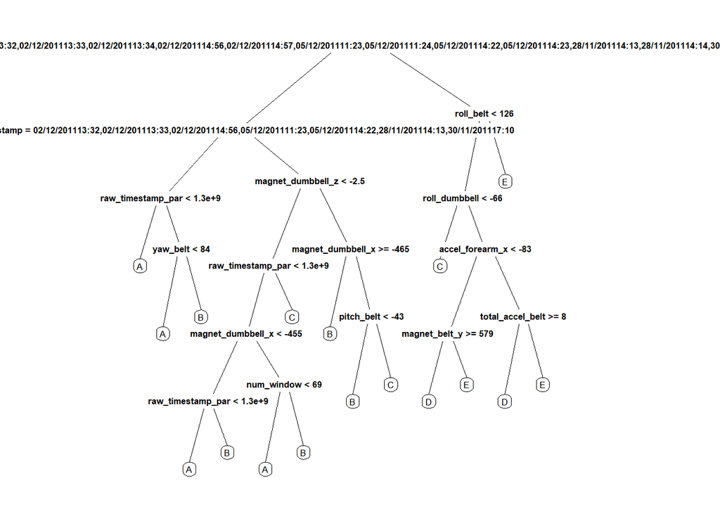

```r
dt <- rpart(classe ~ ., data = train_final, method = "class")
prp(dt)
```

We test the performance of above Decision Tree on the Validation set using the confusion matrix.

```r
predict_dt <- predict(dt, validation, type = "class")
confusionMatrix(validation$classe, predict_dt)
```

```
## Confusion Matrix and Statistics
##
##           Reference
## Prediction    A    B    C    D    E
##          A 1607   48   19    0    0
##          B   48  939  148    4    0
##          C    4   55  948   12    7
##          D    0   43  157  665   99
##          E    0    0   46   73  963
##
## Overall Statistics
##
##                Accuracy : 0.8703
##                  95% CI : (0.8615, 0.8788)
##     No Information Rate : 0.2819
##     P-Value [Acc > NIR] : < 2.2e-16
##
##                   Kappa : 0.836
##
##  Mcnemar's Test P-Value : NA
##
## Statistics by Class:
##
##                      Class: A Class: B Class: C Class: D Class: E
## Sensitivity            0.9687   0.8654   0.7193   0.8820   0.9008
## Specificity            0.9841   0.9583   0.9829   0.9417   0.9753
## Pos Pred Value         0.9600   0.8244   0.9240   0.6898   0.8900
## Neg Pred Value         0.9877   0.9692   0.9239   0.9819   0.9779
## Prevalence             0.2819   0.1844   0.2240   0.1281   0.1816
## Detection Rate         0.2731   0.1596   0.1611   0.1130   0.1636
## Detection Prevalence   0.2845   0.1935   0.1743   0.1638   0.1839
## Balanced Accuracy      0.9764   0.9119   0.8511   0.9118   0.9381
```

## 8.2 Random Forest Modelling

To improve accuracy, we use **Random Forest** algorithm

```r
rf <- train(classe ~ ., data = train_final, method = "rf", trControl = trainControl(method = "cv", 5), ntree = 100)
rf
```

```
## Random Forest
##
## 13737 samples
##    56 predictor
##     5 classes: 'A', 'B', 'C', 'D', 'E'
##
## No pre-processing
## Resampling: Cross-Validated (5 fold)
## Summary of sample sizes: 10989, 10989, 10990, 10990, 10990
## Resampling results across tuning parameters:
##
##   mtry  Accuracy   Kappa
##    2    0.9898813  0.9871992
##   38    0.9983986  0.9979745
##   74    0.9975977  0.9969614
##
## Accuracy was used to select the optimal model using the largest value.
## The final value used for the model was mtry = 38.
```

We test the performance of above Random Forest on the Validation set using the confusion matrix.

```r
predict_rf <- predict(rf, validation)
confusionMatrix(validation$classe, predict_rf)
```

```
## Confusion Matrix and Statistics
##
##           Reference
## Prediction    A    B    C    D    E
##          A 1674    0    0    0    0
##          B    0 1139    0    0    0
##          C    0    1 1025    0    0
##          D    0    0    1  963    0
##          E    0    0    0    0 1082
##
## Overall Statistics
##
##                Accuracy : 0.9997
##                  95% CI : (0.9988, 1)
##     No Information Rate : 0.2845
##     P-Value [Acc > NIR] : < 2.2e-16
##
##                   Kappa : 0.9996
##
##  Mcnemar's Test P-Value : NA
##
## Statistics by Class:
##
##                      Class: A Class: B Class: C Class: D Class: E
## Sensitivity            1.0000   0.9991   0.9990   1.0000   1.0000
## Specificity            1.0000   1.0000   0.9998   0.9998   1.0000
## Pos Pred Value         1.0000   1.0000   0.9990   0.9990   1.0000
## Neg Pred Value         1.0000   0.9998   0.9998   1.0000   1.0000
## Prevalence             0.2845   0.1937   0.1743   0.1636   0.1839
## Detection Rate         0.2845   0.1935   0.1742   0.1636   0.1839
## Detection Prevalence   0.2845   0.1935   0.1743   0.1638   0.1839
## Balanced Accuracy      1.0000   0.9996   0.9994   0.9999   1.0000
```

# 9 Prediction Output of Test Data

We use Random Forest model to predict the manner of exercise of the test data set

```r
predict(rf,test_final)
```

```
##  [1] B A B A A E D B A A B C B A E E A B B B
## Levels: A B C D E
```